# Risk Factor Analysis

## Outcome Variable

**Outcome Variable:** wasted

## Predictor Variables

**Intervention Variable:** nrooms

**Adjustment Set:**

- arm
- sex
- W_mage
- meducyrs
- feducyrs
- hhwealth_quart
- hfoodsec
- W_mhtcm
- W_mwtkg
- W_mbmi
- W_nchldlt5
- W_parity
- impfloor
- impsan
- safeh20
- delta_W_mage
- delta_meducyrs
- delta_feducyrs
- delta_hhwealth_quart
- delta_hfoodsec
- delta_W_mhtcm
- delta_W_mwtkg
- delta_W_mbmi
- delta_W_nchldlt5
- delta_W_parity
- delta_impfloor
- delta_impsan
- delta_safeh20

## Stratifying Variables

The analysis was stratified on these variable(s):

- agecat
- studyid
- country

## Data Summary

| agecat | studyid | country | nrooms | wasted | n_cell | n |
| --- | --- | --- | --- | --- | --- | --- |
| Birth | ki0047075b-MAL-ED | BANGLADESH | 4+ | 0 | 11 | 201 |
| Birth | ki0047075b-MAL-ED | BANGLADESH | 4+ | 1 | 1 | 201 |
| Birth | ki0047075b-MAL-ED | BANGLADESH | 1 | 0 | 94 | 201 |
| Birth | ki0047075b-MAL-ED | BANGLADESH | 1 | 1 | 27 | 201 |
| Birth | ki0047075b-MAL-ED | BANGLADESH | 2 | 0 | 40 | 201 |
| Birth | ki0047075b-MAL-ED | BANGLADESH | 2 | 1 | 3 | 201 |
| Birth | ki0047075b-MAL-ED | BANGLADESH | 3 | 0 | 21 | 201 |
| Birth | ki0047075b-MAL-ED | BANGLADESH | 3 | 1 | 4 | 201 |
| Birth | ki0047075b-MAL-ED | BRAZIL | 4+ | 0 | 28 | 57 |
| Birth | ki0047075b-MAL-ED | BRAZIL | 4+ | 1 | 1 | 57 |
| Birth | ki0047075b-MAL-ED | BRAZIL | 1 | 0 | 0 | 57 |
| Birth | ki0047075b-MAL-ED | BRAZIL | 1 | 1 | 0 | 57 |
| Birth | ki0047075b-MAL-ED | BRAZIL | 2 | 0 | 9 | 57 |
| Birth | ki0047075b-MAL-ED | BRAZIL | 2 | 1 | 1 | 57 |
| Birth | ki0047075b-MAL-ED | BRAZIL | 3 | 0 | 18 | 57 |
| Birth | ki0047075b-MAL-ED | BRAZIL | 3 | 1 | 0 | 57 |
| Birth | ki0047075b-MAL-ED | INDIA | 4+ | 0 | 2 | 39 |
| Birth | ki0047075b-MAL-ED | INDIA | 4+ | 1 | 0 | 39 |
| Birth | ki0047075b-MAL-ED | INDIA | 1 | 0 | 14 | 39 |
| Birth | ki0047075b-MAL-ED | INDIA | 1 | 1 | 3 | 39 |
| Birth | ki0047075b-MAL-ED | INDIA | 2 | 0 | 14 | 39 |
| Birth | ki0047075b-MAL-ED | INDIA | 2 | 1 | 2 | 39 |
| Birth | ki0047075b-MAL-ED | INDIA | 3 | 0 | 4 | 39 |
| Birth | ki0047075b-MAL-ED | INDIA | 3 | 1 | 0 | 39 |
| Birth | ki0047075b-MAL-ED | NEPAL | 4+ | 0 | 14 | 25 |
| Birth | ki0047075b-MAL-ED | NEPAL | 4+ | 1 | 1 | 25 |
| Birth | ki0047075b-MAL-ED | NEPAL | 1 | 0 | 6 | 25 |
| Birth | ki0047075b-MAL-ED | NEPAL | 1 | 1 | 0 | 25 |
| Birth | ki0047075b-MAL-ED | NEPAL | 2 | 0 | 2 | 25 |
| Birth | ki0047075b-MAL-ED | NEPAL | 2 | 1 | 0 | 25 |

[output cut: 354 more lines]

The following strata were considered:

- agecat: 24 months, studyid: ki0047075b-MAL-ED, country: BANGLADESH
- agecat: 24 months, studyid: ki0047075b-MAL-ED, country: BRAZIL
- agecat: 24 months, studyid: ki0047075b-MAL-ED, country: INDIA
- agecat: 24 months, studyid: ki0047075b-MAL-ED, country: NEPAL
- agecat: 24 months, studyid: ki0047075b-MAL-ED, country: PERU
- agecat: 24 months, studyid: ki0047075b-MAL-ED, country: SOUTH AFRICA
- agecat: 24 months, studyid: ki0047075b-MAL-ED, country: TANZANIA, UNITED REPUBLIC OF
- agecat: 24 months, studyid: ki1000108-CMC-V-BCS-2002, country: INDIA
- agecat: 24 months, studyid: ki1000108-IRC, country: INDIA
- agecat: 24 months, studyid: ki1017093b-PROVIDE, country: BANGLADESH
- agecat: 24 months, studyid: ki1017093c-NIH-Crypto, country: BANGLADESH
- agecat: 24 months, studyid: ki1113344-GMS-Nepal, country: NEPAL
- agecat: 24 months, studyid: ki1114097-CONTENT, country: PERU
- agecat: 24 months, studyid: ki1135781-COHORTS, country: INDIA
- agecat: 24 months, studyid: kiGH5241-JiVitA-3, country: BANGLADESH
- agecat: 24 months, studyid: kiGH5241-JiVitA-4, country: BANGLADESH
- agecat: 6 months, studyid: ki0047075b-MAL-ED, country: BANGLADESH
- agecat: 6 months, studyid: ki0047075b-MAL-ED, country: BRAZIL
- agecat: 6 months, studyid: ki0047075b-MAL-ED, country: INDIA
- agecat: 6 months, studyid: ki0047075b-MAL-ED, country: NEPAL
- agecat: 6 months, studyid: ki0047075b-MAL-ED, country: PERU
- agecat: 6 months, studyid: ki0047075b-MAL-ED, country: SOUTH AFRICA
- agecat: 6 months, studyid: ki0047075b-MAL-ED, country: TANZANIA, UNITED REPUBLIC OF
- agecat: 6 months, studyid: ki1000108-CMC-V-BCS-2002, country: INDIA
- agecat: 6 months, studyid: ki1000108-IRC, country: INDIA
- agecat: 6 months, studyid: ki1017093b-PROVIDE, country: BANGLADESH
- agecat: 6 months, studyid: ki1017093c-NIH-Crypto, country: BANGLADESH
- agecat: 6 months, studyid: ki1113344-GMS-Nepal, country: NEPAL
- agecat: 6 months, studyid: ki1114097-CONTENT, country: PERU
- agecat: 6 months, studyid: ki1135781-COHORTS, country: INDIA
- agecat: 6 months, studyid: kiGH5241-JiVitA-3, country: BANGLADESH
- agecat: 6 months, studyid: kiGH5241-JiVitA-4, country: BANGLADESH
- agecat: Birth, studyid: ki0047075b-MAL-ED, country: BANGLADESH
- agecat: Birth, studyid: ki0047075b-MAL-ED, country: BRAZIL
- agecat: Birth, studyid: ki0047075b-MAL-ED, country: INDIA
- agecat: Birth, studyid: ki0047075b-MAL-ED, country: NEPAL
- agecat: Birth, studyid: ki0047075b-MAL-ED, country: PERU
- agecat: Birth, studyid: ki0047075b-MAL-ED, country: SOUTH AFRICA
- agecat: Birth, studyid: ki0047075b-MAL-ED, country: TANZANIA, UNITED REPUBLIC OF
- agecat: Birth, studyid: ki1000108-CMC-V-BCS-2002, country: INDIA
- agecat: Birth, studyid: ki1000108-IRC, country: INDIA
- agecat: Birth, studyid: ki1017093b-PROVIDE, country: BANGLADESH
- agecat: Birth, studyid: ki1017093c-NIH-Crypto, country: BANGLADESH
- agecat: Birth, studyid: ki1113344-GMS-Nepal, country: NEPAL
- agecat: Birth, studyid: ki1114097-CONTENT, country: PERU
- agecat: Birth, studyid: ki1135781-COHORTS, country: INDIA
- agecat: Birth, studyid: kiGH5241-JiVitA-3, country: BANGLADESH
- agecat: Birth, studyid: kiGH5241-JiVitA-4, country: BANGLADESH

### Dropped Strata

Some strata were dropped due to rare outcomes:

- agecat: Birth, studyid: ki0047075b-MAL-ED, country: BANGLADESH
- agecat: Birth, studyid: ki0047075b-MAL-ED, country: BRAZIL
- agecat: Birth, studyid: ki0047075b-MAL-ED, country: INDIA
- agecat: Birth, studyid: ki0047075b-MAL-ED, country: NEPAL
- agecat: Birth, studyid: ki0047075b-MAL-ED, country: PERU
- agecat: Birth, studyid: ki0047075b-MAL-ED, country: SOUTH AFRICA
- agecat: Birth, studyid: ki0047075b-MAL-ED, country: TANZANIA, UNITED REPUBLIC OF
- agecat: Birth, studyid: ki1000108-CMC-V-BCS-2002, country: INDIA
- agecat: Birth, studyid: ki1017093b-PROVIDE, country: BANGLADESH
- agecat: Birth, studyid: ki1114097-CONTENT, country: PERU
- agecat: 6 months, studyid: ki0047075b-MAL-ED, country: BANGLADESH
- agecat: 6 months, studyid: ki0047075b-MAL-ED, country: BRAZIL
- agecat: 6 months, studyid: ki0047075b-MAL-ED, country: INDIA
- agecat: 6 months, studyid: ki0047075b-MAL-ED, country: NEPAL
- agecat: 6 months, studyid: ki0047075b-MAL-ED, country: PERU
- agecat: 6 months, studyid: ki0047075b-MAL-ED, country: SOUTH AFRICA
- agecat: 6 months, studyid: ki0047075b-MAL-ED, country: TANZANIA, UNITED REPUBLIC OF
- agecat: 6 months, studyid: ki1000108-CMC-V-BCS-2002, country: INDIA
- agecat: 6 months, studyid: ki1000108-IRC, country: INDIA
- agecat: 6 months, studyid: ki1017093b-PROVIDE, country: BANGLADESH
- agecat: 6 months, studyid: ki1017093c-NIH-Crypto, country: BANGLADESH
- agecat: 6 months, studyid: ki1113344-GMS-Nepal, country: NEPAL
- agecat: 6 months, studyid: ki1114097-CONTENT, country: PERU
- agecat: 6 months, studyid: ki1135781-COHORTS, country: INDIA
- agecat: 24 months, studyid: ki0047075b-MAL-ED, country: BANGLADESH
- agecat: 24 months, studyid: ki0047075b-MAL-ED, country: BRAZIL
- agecat: 24 months, studyid: ki0047075b-MAL-ED, country: INDIA
- agecat: 24 months, studyid: ki0047075b-MAL-ED, country: NEPAL
- agecat: 24 months, studyid: ki0047075b-MAL-ED, country: PERU
- agecat: 24 months, studyid: ki0047075b-MAL-ED, country: SOUTH AFRICA
- agecat: 24 months, studyid: ki0047075b-MAL-ED, country: TANZANIA, UNITED REPUBLIC OF
- agecat: 24 months, studyid: ki1000108-CMC-V-BCS-2002, country: INDIA
- agecat: 24 months, studyid: ki1000108-IRC, country: INDIA
- agecat: 24 months, studyid: ki1017093b-PROVIDE, country: BANGLADESH
- agecat: 24 months, studyid: ki1017093c-NIH-Crypto, country: BANGLADESH
- agecat: 24 months, studyid: ki1113344-GMS-Nepal, country: NEPAL
- agecat: 24 months, studyid: ki1114097-CONTENT, country: PERU
- agecat: 24 months, studyid: ki1135781-COHORTS, country: INDIA

## Methods Detail

We’re interested in the causal parameters $E[Y_a]$ for all values of $a \in \mathcal{A}$. These parameters represent the mean outcome if, possibly contrary to fact, we intervened to set all units to have $A=a$. Under the randomization and positivity assumptions, these are identified by the statistical parameters $\psi_a=E_W[E_{Y|A,W}(Y|A=a,W)]$. In addition, we’re interested in the mean of $Y$, $E[Y]$ under no intervention (the observed mean). We will estimate these parameters by using SuperLearner to fit the relevant likelihood factors – $E_{Y|A,W}(Y|A=a,W)$ and $p(A=a|W)$, and then updating our likelihood fit using a joint TMLE.

For unadjusted analyses ($W=\{\}$), initial likelihoods were estimated using Lrnr_glm to estimate the simple $E(Y|A)$ and Lrnr_mean to estimate $p(A)$. For adjusted analyses, a small library containing Lrnr_glmnet, Lrnr_xgboost, and Lrnr_mean was used.

Having estimated these parameters, we will then use the delta method to estimate relative risks and attributable risks relative to a prespecified baseline level of $A$.

# Results Detail

## Results Plots

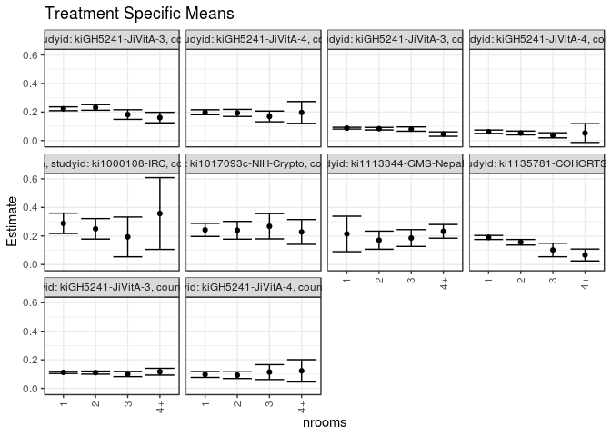

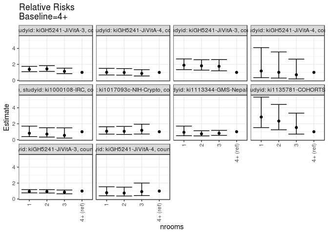

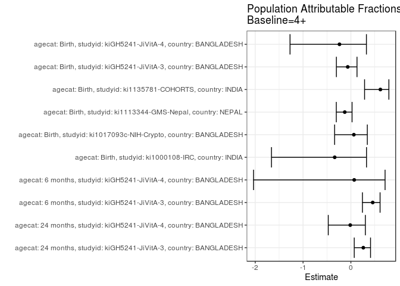

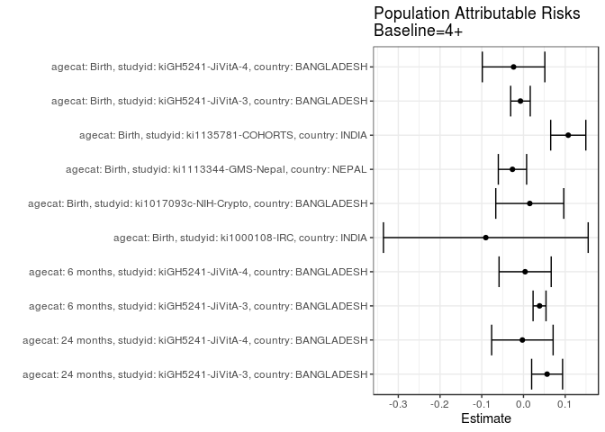

## Results Table

### Parameter: TSM

| agecat | studyid | country | intervention_level | baseline_level | estimate | ci_lower | ci_upper |
| --- | --- | --- | --- | --- | --- | --- | --- |
| Birth | ki1000108-IRC | INDIA | 4+ | NA | 0.3571429 | 0.1057806 | 0.6085051 |
| Birth | ki1000108-IRC | INDIA | 1 | NA | 0.2884615 | 0.2172637 | 0.3596594 |
| Birth | ki1000108-IRC | INDIA | 2 | NA | 0.2500000 | 0.1781673 | 0.3218327 |
| Birth | ki1000108-IRC | INDIA | 3 | NA | 0.1935484 | 0.0542683 | 0.3328284 |
| Birth | ki1017093c-NIH-Crypto | BANGLADESH | 4+ | NA | 0.2282009 | 0.1414406 | 0.3149613 |
| Birth | ki1017093c-NIH-Crypto | BANGLADESH | 1 | NA | 0.2424249 | 0.1967322 | 0.2881175 |
| Birth | ki1017093c-NIH-Crypto | BANGLADESH | 2 | NA | 0.2399195 | 0.1774864 | 0.3023526 |
| Birth | ki1017093c-NIH-Crypto | BANGLADESH | 3 | NA | 0.2679267 | 0.1793949 | 0.3564585 |
| Birth | ki1113344-GMS-Nepal | NEPAL | 4+ | NA | 0.2323232 | 0.1842565 | 0.2803899 |
| Birth | ki1113344-GMS-Nepal | NEPAL | 1 | NA | 0.2142857 | 0.0900943 | 0.3384771 |
| Birth | ki1113344-GMS-Nepal | NEPAL | 2 | NA | 0.1703704 | 0.1069017 | 0.2338390 |
| Birth | ki1113344-GMS-Nepal | NEPAL | 3 | NA | 0.1856287 | 0.1266137 | 0.2446438 |
| Birth | ki1135781-COHORTS | INDIA | 4+ | NA | 0.0666667 | 0.0250085 | 0.1083249 |
| Birth | ki1135781-COHORTS | INDIA | 1 | NA | 0.1896492 | 0.1753277 | 0.2039707 |
| Birth | ki1135781-COHORTS | INDIA | 2 | NA | 0.1558735 | 0.1363621 | 0.1753849 |
| Birth | ki1135781-COHORTS | INDIA | 3 | NA | 0.1019108 | 0.0545830 | 0.1492387 |
| Birth | kiGH5241-JiVitA-3 | BANGLADESH | 4+ | NA | 0.1168580 | 0.0931857 | 0.1405304 |
| Birth | kiGH5241-JiVitA-3 | BANGLADESH | 1 | NA | 0.1119704 | 0.1046175 | 0.1193233 |
| Birth | kiGH5241-JiVitA-3 | BANGLADESH | 2 | NA | 0.1103022 | 0.0998381 | 0.1207662 |
| Birth | kiGH5241-JiVitA-3 | BANGLADESH | 3 | NA | 0.1006701 | 0.0823328 | 0.1190075 |
| Birth | kiGH5241-JiVitA-4 | BANGLADESH | 4+ | NA | 0.1231334 | 0.0452421 | 0.2010247 |
| Birth | kiGH5241-JiVitA-4 | BANGLADESH | 1 | NA | 0.0974826 | 0.0770110 | 0.1179543 |
| Birth | kiGH5241-JiVitA-4 | BANGLADESH | 2 | NA | 0.0928368 | 0.0693785 | 0.1162952 |
| Birth | kiGH5241-JiVitA-4 | BANGLADESH | 3 | NA | 0.1143283 | 0.0621128 | 0.1665437 |
| 6 months | kiGH5241-JiVitA-3 | BANGLADESH | 4+ | NA | 0.0459426 | 0.0304775 | 0.0614076 |
| 6 months | kiGH5241-JiVitA-3 | BANGLADESH | 1 | NA | 0.0872658 | 0.0810137 | 0.0935180 |
| 6 months | kiGH5241-JiVitA-3 | BANGLADESH | 2 | NA | 0.0837850 | 0.0748107 | 0.0927592 |
| 6 months | kiGH5241-JiVitA-3 | BANGLADESH | 3 | NA | 0.0809803 | 0.0658112 | 0.0961494 |
| 6 months | kiGH5241-JiVitA-4 | BANGLADESH | 4+ | NA | 0.0530104 | -0.0127073 | 0.1187281 |
| 6 months | kiGH5241-JiVitA-4 | BANGLADESH | 1 | NA | 0.0621425 | 0.0502207 | 0.0740642 |
| 6 months | kiGH5241-JiVitA-4 | BANGLADESH | 2 | NA | 0.0534141 | 0.0401416 | 0.0666867 |
| 6 months | kiGH5241-JiVitA-4 | BANGLADESH | 3 | NA | 0.0371675 | 0.0192582 | 0.0550768 |
| 24 months | kiGH5241-JiVitA-3 | BANGLADESH | 4+ | NA | 0.1612563 | 0.1243314 | 0.1981813 |
| 24 months | kiGH5241-JiVitA-3 | BANGLADESH | 1 | NA | 0.2230975 | 0.2097000 | 0.2364950 |
| 24 months | kiGH5241-JiVitA-3 | BANGLADESH | 2 | NA | 0.2324258 | 0.2127577 | 0.2520938 |
| 24 months | kiGH5241-JiVitA-3 | BANGLADESH | 3 | NA | 0.1824770 | 0.1487944 | 0.2161596 |
| 24 months | kiGH5241-JiVitA-4 | BANGLADESH | 4+ | NA | 0.1971403 | 0.1205596 | 0.2737210 |
| 24 months | kiGH5241-JiVitA-4 | BANGLADESH | 1 | NA | 0.1986668 | 0.1813763 | 0.2159573 |
| 24 months | kiGH5241-JiVitA-4 | BANGLADESH | 2 | NA | 0.1939388 | 0.1690077 | 0.2188699 |
| 24 months | kiGH5241-JiVitA-4 | BANGLADESH | 3 | NA | 0.1694685 | 0.1318420 | 0.2070951 |

### Parameter: E(Y)

| agecat | studyid | country | intervention_level | baseline_level | estimate | ci_lower | ci_upper |
| --- | --- | --- | --- | --- | --- | --- | --- |
| Birth | ki1000108-IRC | INDIA | NA | NA | 0.2668622 | 0.2198462 | 0.3138781 |
| Birth | ki1017093c-NIH-Crypto | BANGLADESH | NA | NA | 0.2432815 | 0.2116319 | 0.2749310 |
| Birth | ki1113344-GMS-Nepal | NEPAL | NA | NA | 0.2059282 | 0.1745993 | 0.2372572 |
| Birth | ki1135781-COHORTS | INDIA | NA | NA | 0.1740009 | 0.1628660 | 0.1851358 |
| Birth | kiGH5241-JiVitA-3 | BANGLADESH | NA | NA | 0.1096225 | 0.1044939 | 0.1147512 |
| Birth | kiGH5241-JiVitA-4 | BANGLADESH | NA | NA | 0.0994152 | 0.0840401 | 0.1147903 |
| 6 months | kiGH5241-JiVitA-3 | BANGLADESH | NA | NA | 0.0844810 | 0.0796719 | 0.0892901 |
| 6 months | kiGH5241-JiVitA-4 | BANGLADESH | NA | NA | 0.0569712 | 0.0481278 | 0.0658146 |
| 24 months | kiGH5241-JiVitA-3 | BANGLADESH | NA | NA | 0.2179025 | 0.2080266 | 0.2277783 |
| 24 months | kiGH5241-JiVitA-4 | BANGLADESH | NA | NA | 0.1945032 | 0.1812962 | 0.2077102 |

### Parameter: RR

| agecat | studyid | country | intervention_level | baseline_level | estimate | ci_lower | ci_upper |
| --- | --- | --- | --- | --- | --- | --- | --- |
| Birth | ki1000108-IRC | INDIA | 4+ | 4+ | 1.0000000 | 1.0000000 | 1.000000 |
| Birth | ki1000108-IRC | INDIA | 1 | 4+ | 0.8076923 | 0.3831181 | 1.702783 |
| Birth | ki1000108-IRC | INDIA | 2 | 4+ | 0.7000000 | 0.3272990 | 1.497102 |
| Birth | ki1000108-IRC | INDIA | 3 | 4+ | 0.5419355 | 0.1980599 | 1.482855 |
| Birth | ki1017093c-NIH-Crypto | BANGLADESH | 4+ | 4+ | 1.0000000 | 1.0000000 | 1.000000 |
| Birth | ki1017093c-NIH-Crypto | BANGLADESH | 1 | 4+ | 1.0623308 | 0.6950514 | 1.623688 |
| Birth | ki1017093c-NIH-Crypto | BANGLADESH | 2 | 4+ | 1.0513521 | 0.6633614 | 1.666273 |
| Birth | ki1017093c-NIH-Crypto | BANGLADESH | 3 | 4+ | 1.1740824 | 0.7096895 | 1.942356 |
| Birth | ki1113344-GMS-Nepal | NEPAL | 4+ | 4+ | 1.0000000 | 1.0000000 | 1.000000 |
| Birth | ki1113344-GMS-Nepal | NEPAL | 1 | 4+ | 0.9223602 | 0.4984751 | 1.706702 |
| Birth | ki1113344-GMS-Nepal | NEPAL | 2 | 4+ | 0.7333333 | 0.4788895 | 1.122968 |
| Birth | ki1113344-GMS-Nepal | NEPAL | 3 | 4+ | 0.7990107 | 0.5467877 | 1.167579 |
| Birth | ki1135781-COHORTS | INDIA | 4+ | 4+ | 1.0000000 | 1.0000000 | 1.000000 |
| Birth | ki1135781-COHORTS | INDIA | 1 | 4+ | 2.8447378 | 1.5159635 | 5.338211 |
| Birth | ki1135781-COHORTS | INDIA | 2 | 4+ | 2.3381024 | 1.2362126 | 4.422154 |
| Birth | ki1135781-COHORTS | INDIA | 3 | 4+ | 1.5286624 | 0.7017657 | 3.329899 |
| Birth | kiGH5241-JiVitA-3 | BANGLADESH | 4+ | 4+ | 1.0000000 | 1.0000000 | 1.000000 |
| Birth | kiGH5241-JiVitA-3 | BANGLADESH | 1 | 4+ | 0.9581746 | 0.7746076 | 1.185243 |
| Birth | kiGH5241-JiVitA-3 | BANGLADESH | 2 | 4+ | 0.9438987 | 0.7550995 | 1.179904 |
| Birth | kiGH5241-JiVitA-3 | BANGLADESH | 3 | 4+ | 0.8614735 | 0.6565991 | 1.130273 |
| Birth | kiGH5241-JiVitA-4 | BANGLADESH | 4+ | 4+ | 1.0000000 | 1.0000000 | 1.000000 |
| Birth | kiGH5241-JiVitA-4 | BANGLADESH | 1 | 4+ | 0.7916833 | 0.4082089 | 1.535396 |
| Birth | kiGH5241-JiVitA-4 | BANGLADESH | 2 | 4+ | 0.7539532 | 0.3817388 | 1.489095 |
| Birth | kiGH5241-JiVitA-4 | BANGLADESH | 3 | 4+ | 0.9284911 | 0.4300938 | 2.004437 |
| 6 months | kiGH5241-JiVitA-3 | BANGLADESH | 4+ | 4+ | 1.0000000 | 1.0000000 | 1.000000 |
| 6 months | kiGH5241-JiVitA-3 | BANGLADESH | 1 | 4+ | 1.8994552 | 1.3437074 | 2.685056 |
| 6 months | kiGH5241-JiVitA-3 | BANGLADESH | 2 | 4+ | 1.8236895 | 1.2835255 | 2.591178 |
| 6 months | kiGH5241-JiVitA-3 | BANGLADESH | 3 | 4+ | 1.7626427 | 1.1938366 | 2.602458 |
| 6 months | kiGH5241-JiVitA-4 | BANGLADESH | 4+ | 4+ | 1.0000000 | 1.0000000 | 1.000000 |
| 6 months | kiGH5241-JiVitA-4 | BANGLADESH | 1 | 4+ | 1.1722698 | 0.3343895 | 4.109628 |
| 6 months | kiGH5241-JiVitA-4 | BANGLADESH | 2 | 4+ | 1.0076167 | 0.2846518 | 3.566783 |
| 6 months | kiGH5241-JiVitA-4 | BANGLADESH | 3 | 4+ | 0.7011361 | 0.1848197 | 2.659846 |
| 24 months | kiGH5241-JiVitA-3 | BANGLADESH | 4+ | 4+ | 1.0000000 | 1.0000000 | 1.000000 |
| 24 months | kiGH5241-JiVitA-3 | BANGLADESH | 1 | 4+ | 1.3834961 | 1.0925998 | 1.751841 |
| 24 months | kiGH5241-JiVitA-3 | BANGLADESH | 2 | 4+ | 1.4413435 | 1.1237863 | 1.848635 |
| 24 months | kiGH5241-JiVitA-3 | BANGLADESH | 3 | 4+ | 1.1315960 | 0.8379764 | 1.528097 |
| 24 months | kiGH5241-JiVitA-4 | BANGLADESH | 4+ | 4+ | 1.0000000 | 1.0000000 | 1.000000 |
| 24 months | kiGH5241-JiVitA-4 | BANGLADESH | 1 | 4+ | 1.0077432 | 0.6757849 | 1.502766 |
| 24 months | kiGH5241-JiVitA-4 | BANGLADESH | 2 | 4+ | 0.9837602 | 0.6539400 | 1.479928 |
| 24 months | kiGH5241-JiVitA-4 | BANGLADESH | 3 | 4+ | 0.8596341 | 0.5523362 | 1.337900 |

### Parameter: PAR

| agecat | studyid | country | intervention_level | baseline_level | estimate | ci_lower | ci_upper |
| --- | --- | --- | --- | --- | --- | --- | --- |
| Birth | ki1000108-IRC | INDIA | 4+ | NA | -0.0902807 | -0.3356486 | 0.1550872 |
| Birth | ki1017093c-NIH-Crypto | BANGLADESH | 4+ | NA | 0.0150806 | -0.0663839 | 0.0965451 |
| Birth | ki1113344-GMS-Nepal | NEPAL | 4+ | NA | -0.0263950 | -0.0603201 | 0.0075301 |
| Birth | ki1135781-COHORTS | INDIA | 4+ | NA | 0.1073342 | 0.0652317 | 0.1494368 |
| Birth | kiGH5241-JiVitA-3 | BANGLADESH | 4+ | NA | -0.0072355 | -0.0306735 | 0.0162025 |
| Birth | kiGH5241-JiVitA-4 | BANGLADESH | 4+ | NA | -0.0237182 | -0.0986793 | 0.0512429 |
| 6 months | kiGH5241-JiVitA-3 | BANGLADESH | 4+ | NA | 0.0385385 | 0.0230255 | 0.0540514 |
| 6 months | kiGH5241-JiVitA-4 | BANGLADESH | 4+ | NA | 0.0039608 | -0.0585315 | 0.0664532 |
| 24 months | kiGH5241-JiVitA-3 | BANGLADESH | 4+ | NA | 0.0566461 | 0.0195668 | 0.0937255 |
| 24 months | kiGH5241-JiVitA-4 | BANGLADESH | 4+ | NA | -0.0026371 | -0.0763076 | 0.0710334 |

### Parameter: PAF

| agecat | studyid | country | intervention_level | baseline_level | estimate | ci_lower | ci_upper |
| --- | --- | --- | --- | --- | --- | --- | --- |
| Birth | ki1000108-IRC | INDIA | 4+ | NA | -0.3383046 | -1.6601876 | 0.3267170 |
| Birth | ki1017093c-NIH-Crypto | BANGLADESH | 4+ | NA | 0.0619881 | -0.3403249 | 0.3435425 |
| Birth | ki1113344-GMS-Nepal | NEPAL | 4+ | NA | -0.1281757 | -0.3049988 | 0.0246885 |
| Birth | ki1135781-COHORTS | INDIA | 4+ | NA | 0.6168602 | 0.2862315 | 0.7943365 |
| Birth | kiGH5241-JiVitA-3 | BANGLADESH | 4+ | NA | -0.0660038 | -0.3030270 | 0.1279044 |
| Birth | kiGH5241-JiVitA-4 | BANGLADESH | 4+ | NA | -0.2385771 | -1.2721697 | 0.3248422 |
| 6 months | kiGH5241-JiVitA-3 | BANGLADESH | 4+ | NA | 0.4561789 | 0.2411917 | 0.6102555 |
| 6 months | kiGH5241-JiVitA-4 | BANGLADESH | 4+ | NA | 0.0695232 | -2.0355173 | 0.7147811 |
| 24 months | kiGH5241-JiVitA-3 | BANGLADESH | 4+ | NA | 0.2599609 | 0.0703401 | 0.4109052 |
| 24 months | kiGH5241-JiVitA-4 | BANGLADESH | 4+ | NA | -0.0135582 | -0.4726175 | 0.3023984 |